# R Notebook

```r
library("tidyverse")
library("ggplot2")
```

# Exercício 5

Considere o seguinte modelo de geração de dados mostrado abaixo: y = h(x) +ε Nesse modelo, h(x) = 3x+30 consiste na função hipótese verdadeira, muitas vezes desconhecida na prática de ML, e ε é um termo que expressa a incerteza entre os valores da função hipótese verdadeira e a variável de saída ou resposta y. Estatisticamente, ε é interpretado como um ruído, que nesse exercício segue a distribuição de probabilidade Gaussiana com média µ = 0 e desvio padrão σ = 15. A notação em negrito usada ocorre em função de (1.3) ser um modelo vetorial de dados. A variável explanatória x usada será um vetor de valores inteiros de zero (1) a cem (100). Logo, o modelo de dados é formado pelos vetores y, h(x) e ε, sendo cada um com dimensões (número de linhas e colunas) de 100×1. Considere que um grupo de cientistas de dados já realizaram o trabalho de modelagem e encontraram uma função hipótese candidata dada por: hˆ(x) = 2.8x+32

1. Construa esse modelo de geração de dados. Para que seja possível a reprodução de resultados em função do vetor aleatório ε utilize a semente (seed) 123 em seu código.

```r
x = c(1:100)


h_x <- 3*x + 30


set.seed(123)

dist_normal <- rnorm(100, 0, 15)


y <- h_x + dist_normal
```

2. Faça um gráfico de dispersão da variável explanatória x com saída conhecida y.

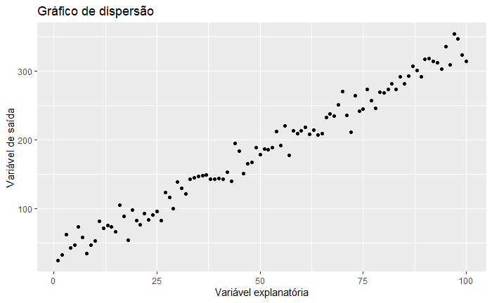

```r
t <- data.frame(x, y)
t %>% ggplot() +
  geom_point(aes(x = x, y = y)) +
  labs(title = "Gráfico de dispersão", x = "Variável explanatória", y = "Variável de saída")
```

• 3) Obtenha o histograma relacionado com a variável de saída y.

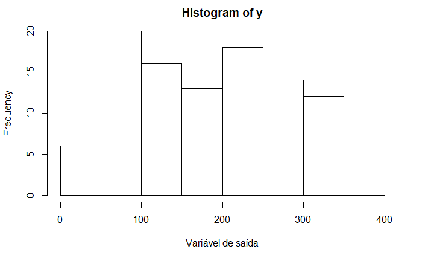

```r
hist(y, xlab = "Variável de saída")
```

• 5) Faça a estimação do erro quadrático médio do modelo proposto pelos cientistas

```r
h_x_estimado <- 2.8*x + 32
#h_x_estimado

MSE = (1/100)*sum(((y - h_x_estimado)^2))
MSE
```

```
[1] 320.9044
```

6. Faça uma análise: o modelo proposto é plausível para explicar os dados? De quais fatores esse desempenho depende? É plausível, porem depende de outros fatores como o X, o ruído e a variância, visto que suas alterações podem variar o MSE.